# Exploratory Data Analysis

## 1. Time Series Plot

**U.S. Dollar Index**

```r
library(ggplot2)
library(tidyverse)
library(plotly)
library(quantmod)

invisible(getSymbols("DX-Y.NYB", src = "yahoo", from = "2005-01-01", to = "2024-12-31"))
dxy <- data.frame(Date = index(`DX-Y.NYB`),
                       Open = `DX-Y.NYB`[, "DX-Y.NYB.Open"],
                       High = `DX-Y.NYB`[, "DX-Y.NYB.High"],
                       Low = `DX-Y.NYB`[, "DX-Y.NYB.Low"],
                       Close = `DX-Y.NYB`[, "DX-Y.NYB.Close"])
dxy <- na.omit(dxy)
colnames(dxy) <- c("Date", "Open", "High", "Low", "Close")

gg <- ggplot(data = dxy, aes(x = Date, y = Close)) +
  geom_line(color='purple') +
  labs(x = "Year", title = "Trend of U.S. Dollar Index")

plotly_gg <- ggplotly(gg)
plotly_gg
```

[interactive chart not shown]

The time series plot of the U.S. Dollar Index reveals a general upward trend, indicating that the value of the U.S. Dollar has been appreciating over time. Despite the presence of trend and weak seasonal patterns, the data does not show clear periodic fluctuations across different years. Based on the observation, I preliminarily consider that the U.S. Dollar Index may follow a multiplicative model. This approach may better capture the dynamic nature of the index’s fluctuations.

**Trade Balance**

```r
bea <- read.csv("./data/bea.csv")
bea$time <- as.Date(bea$time)

gg <- ggplot(bea) +
  geom_line(aes(x = time, y = balance/1000), color = "purple") +
  labs(x = "Year", y = "Billions of Dollars",
  title = "Trends of Trade Balance")

plotly_gg <- ggplotly(gg)
plotly_gg
```

[interactive chart not shown]

**GDP**

```r
gdp <- read.csv("./data/gdp.csv")
gdp$time <- as.Date(gdp$time)
gdp$total <- gdp$consumption + gdp$investment + gdp$net_export + gdp$government
gg <- ggplot(data = gdp, aes(x = time, y = total)) +
  geom_line(color='purple') +
  labs(x = "Year", y = "Billions of Dollars", title = "GDP Over Time")

plotly_gg <- ggplotly(gg)
plotly_gg
```

[interactive chart not shown]

The time series plot of GDP shows a steady increasing trend. Since the raw data we extracted from the BEA is seasonally adjusted at annual rates, there is no noticeable seasonality in the data. Given this, I preliminarily consider the time series to follow an additive model, where the trend is consistent over time and the variations are not influenced by seasonal patterns. This additive model helps capture the general growth trajectory without the need for seasonal adjustments.

**Unemployment Rate**

```r
data_unem <- read.csv("./data/unem.csv", header=TRUE)
data_unem$time <- as.Date(data_unem$time)
gg <- ggplot(data = data_unem, aes(x = time, y = unem)) +
  geom_line(color='purple') +
  labs(x = "Year", y = "Rate", title = "U.S. Unemployment Rate Over Time")

plotly_gg <- ggplotly(gg)
plotly_gg
```

[interactive chart not shown]

**CPI**

```r
data_cpi <- read.csv("./data/cpi.csv", header=TRUE)
data_cpi$time <- as.Date(data_cpi$time)
gg <- ggplot(data = data_cpi, aes(x = time, y = cpi)) +
  geom_line(color='purple') +
  labs(x = "Year", y = "Index", title = "U.S. CPI Over Time")

plotly_gg <- ggplotly(gg)
plotly_gg
```

[interactive chart not shown]

The Consumer Price Index (CPI) also exhibits an upward trend, reflecting the general increase in the cost of living over time. In addition to the trend, there is clear seasonality, with periodic fluctuations occurring at regular intervals throughout the year. Given the consistent nature of these variations, I preliminarily consider the CPI to follow an additive model, where the fluctuations are constant across all levels of the trend. This approach assumes that the seasonal effects do not vary in magnitude as the overall index value changes, making it suitable for capturing the patterns of inflation within the data.

**S&P 500**

```r
getSymbols("^GSPC", src = "yahoo", from = "2005-01-01", to = "2024-12-31")
```

```
[1] "GSPC"
```

```r
data <- data.frame(Date = index(GSPC),
                       Open = GSPC[, "GSPC.Open"],
                       High = GSPC[, "GSPC.High"],
                       Low = GSPC[, "GSPC.Low"],
                       Close = GSPC[, "GSPC.Close"])
colnames(data) <- c("Date", "Open", "High", "Low", "Close")

gg <- ggplot(data = data, aes(x = Date, y = Close)) +
  geom_line(color='purple') +
  labs(x = "Year", y = "Index", title = "S&P 500 Index Over Time")

plotly_gg <- ggplotly(gg)
plotly_gg
```

[interactive chart not shown]

The S&P 500 index displays a clear overall upward trend, reflecting the long-term growth of the stock market. However, like some other financial indicators, it does not show clear seasonality or periodic fluctuations across years. The lack of consistent cyclical patterns suggests that the S&P 500 index may not be significantly influenced by regular seasonal effects. Given this, I preliminarily consider the S&P 500 index to follow an additive model. This model allows for capturing the general market growth while assuming that the variations in the index are not driven by seasonal or periodic factors.

**Gold Price**

```r
xau <- read.csv("./data/xau.csv")
xau$Date <- as.Date(xau$Date)
gg <- ggplot(data = xau, aes(x = Date, y = Price)) +
  geom_line(color='purple') +
  labs(x = "Year", y = "Dollar ($)", title = "Spot Gold in US Dollar")

plotly_gg <- ggplotly(gg)
plotly_gg
```

[interactive chart not shown]

The plot of spot gold prices shows a clear upward trend, reflecting the long-term increase in gold prices. In addition to the overall trend, there is noticeable annual seasonality, indicating that gold prices exhibit periodic fluctuations that repeat each year. Given that the magnitude of the fluctuations appears to vary depending on the level of the trend, I preliminarily consider the gold price data to follow a multiplicative model.

**Global Commodity Price**

```r
gsci <- read.csv("./data/gsci.csv")
gsci$Date <- as.Date(gsci$Date)
gg <- ggplot(data = gsci, aes(x = Date, y = Price)) +
  geom_line(color='purple') +
  labs(x = "Year", y = "Dollar ($)", title = "S&P GSCI Index (USD) Over Time")

plotly_gg <- ggplotly(gg)
plotly_gg
```

[interactive chart not shown]

The plot of GSCI Global Commidity Price Index shows a clear trend, reflecting the long-term changes in commidity prices. In addition to the overall trend, there is noticeable annual seasonality, indicating that commodity prices exhibit periodic fluctuations that repeat each year. Given that the magnitude of the fluctuations appears to vary depending on the level of the trend, I preliminarily consider the index to follow a multiplicative model.

**House Price**

```r
house <- read.csv("./data/house.csv", header=TRUE)
house$time <- as.Date(house$time)

gg <- ggplot(data = house, aes(x = time, y = index)) +
  geom_line(color='purple') +
  labs(x = "Year", y = "Index", title = "House Price Index Over Time")

plotly_gg <- ggplotly(gg)
plotly_gg
```

[interactive chart not shown]

The House Price Index shows a clear overall upward trend, indicating that home prices have generally been rising over time. However, unlike some other economic indicators, the data does not exhibit clearly periodic fluctuations across years, suggesting that seasonal patterns or cyclical variations are not prominent. The plot appears to be very smooth, with minimal volatility, reflecting a stable growth pattern. Given this, I preliminarily consider the House Price Index to follow a additive model.

**International Visitors**

```r
visitors <- read.csv("./data/visitors.csv", header=TRUE)
visitors$time <- as.Date(visitors$time)

gg <- ggplot(data = visitors, aes(x = time, y = count)) +
  geom_line(color='purple') +
  labs(x = "Year", y = "Number of Visitors", title = "Non-U.S. Resident Visitor Arrivals to the U.S.")

plotly_gg <- ggplotly(gg)
plotly_gg
```

[interactive chart not shown]

The data on visitor arrivals to the United States shows a clear seasonal pattern, with noticeable peaks and troughs occurring at regular intervals throughout the year. From 2005 to 2020, there is a stable, gradual increase in the number of visitors, suggesting steady growth over time. Given the consistent nature of the seasonal fluctuations and the overall steady increase, I preliminarily consider the data to follow an additive model. This model assumes that the seasonal variations remain constant across different levels of the overall trend, meaning that the same seasonal effect is added to the trend, regardless of the time period.

Based on the time series plots above, we apply log transformation to the following variables: `USD Index`, `Unemployment Rate`, `Gold Price`, `Global Commodity Price`, and `Number of International Visitors`. This transformation is used to stabilize variance, reduce skewness, and better model the growth patterns in these variables. Taking the logarithm helps to linearize exponential growth trends, especially for variables like `Unemployment Rate` and `Gold Price`, which exhibit high volatility or nonlinear behavior.

## 2. Lag plot

**U.S. Dollar Index**

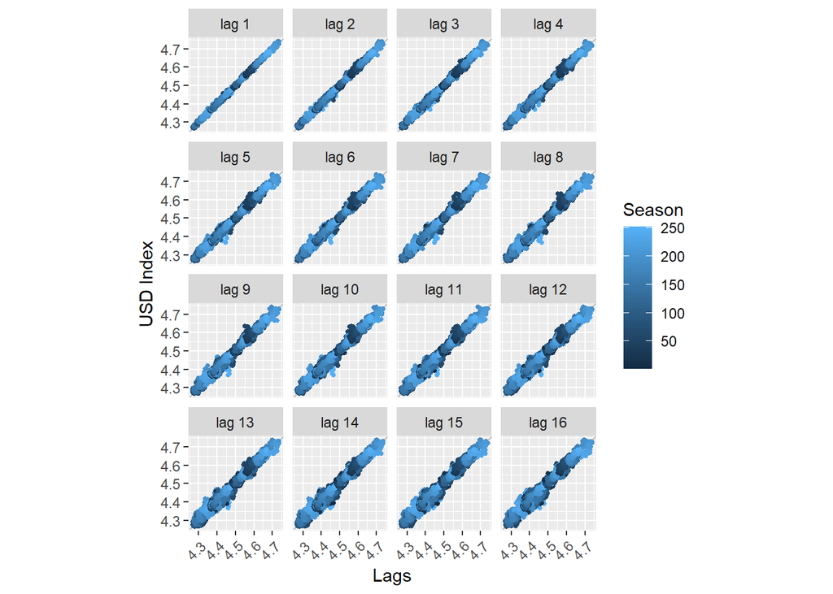

```r
library(forecast)

dxy_ts <- ts(log(dxy$Close), start=c(2005,1), frequency=252)
balance_ts <- ts(bea$balance, start=c(2005,1), end=c(2024,3), frequency=4)
gdp_ts <- ts(gdp$total, start=c(2005,1), end=c(2024,3), frequency=4)
unem_ts <- ts(log(data_unem$unem), start=c(2005,1), end=c(2023,12), frequency=12)
cpi_ts <- ts(data_cpi$cpi, start=c(2005,1), end=c(2023,12), frequency=12)
sp5_ts <- ts(GSPC$GSPC.Close, start=c(2005,1), frequency=252)
xau_ts <- ts(log(xau$Price), start=c(2005,1), end=c(2024,52), frequency=52)
gsci_ts <- ts(log(gsci$Price), start=c(2014,252), frequency=252)
house_ts <- ts(house$index, start=c(2005,1), end=c(2024,4), frequency=4)
visitors_ts <- ts(log(visitors$count), start=c(2005,1), end=c(2024,12), frequency=12)

gglagplot(dxy_ts, do.lines=FALSE) +
          xlab("Lags")+ylab("USD Index") +
          theme(axis.text.x=element_text(angle=45, hjust=1))
```

From the lag plot, we can observe that the U.S. Dollar Index exhibits a strong positive autocorrelation, indicating that past values are highly correlated with future values. Even at lag 16, the autocorrelation remains high, suggesting that the influence of previous data points continues to affect current values over an extended period. This persistence indicates that the U.S. Dollar Index follows a sustained trend, with momentum carrying forward from one period to the next. Such behavior is typical in financial time series, where long-term trends can be heavily influenced by past performance, reinforcing the continuation of the observed pattern.

**Trade Balance**

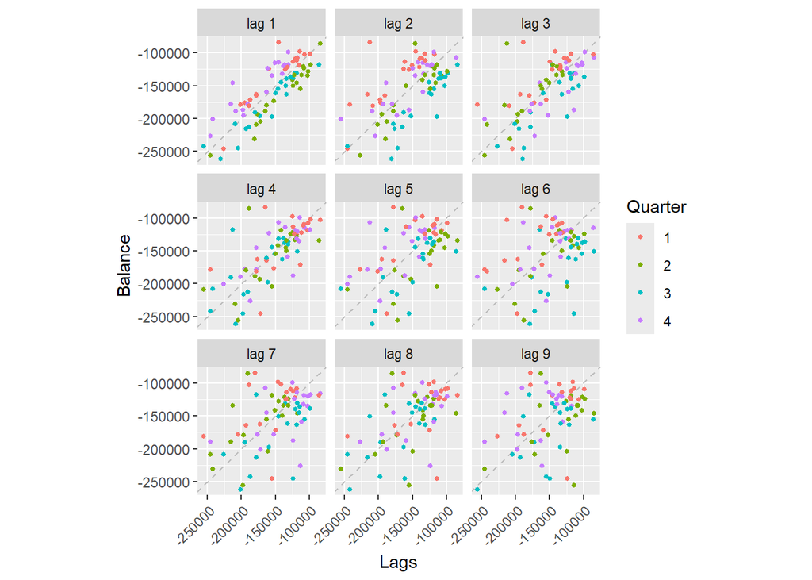

```r
gglagplot(balance_ts, do.lines=FALSE) +
          xlab("Lags")+ylab("Balance") +
          theme(axis.text.x=element_text(angle=45, hjust=1))
```

**GDP**

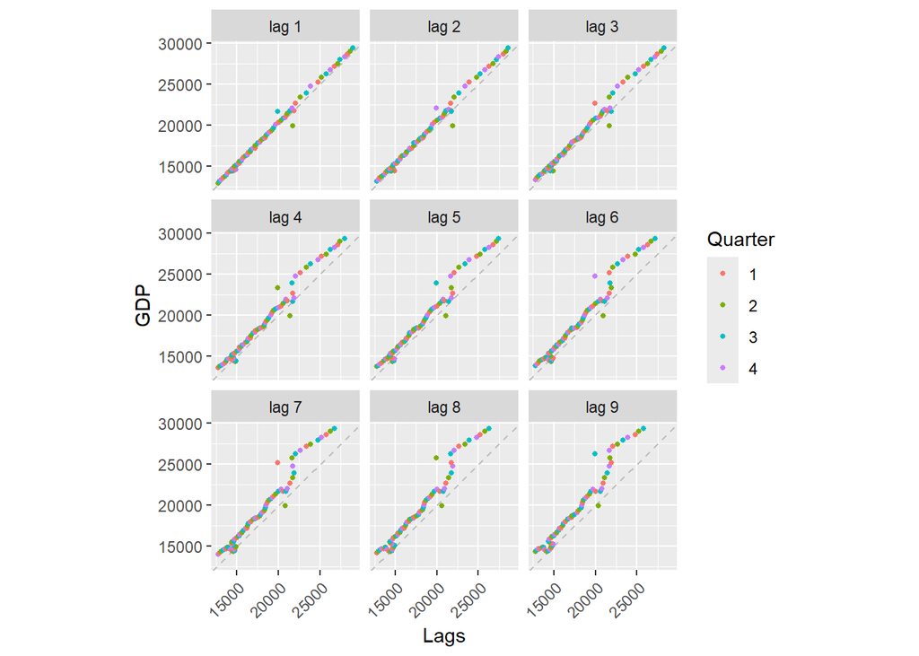

```r
gglagplot(gdp_ts, do.lines=FALSE) +
          xlab("Lags")+ylab("GDP") +
          theme(axis.text.x=element_text(angle=45, hjust=1))
```

**Unemployment Rate**

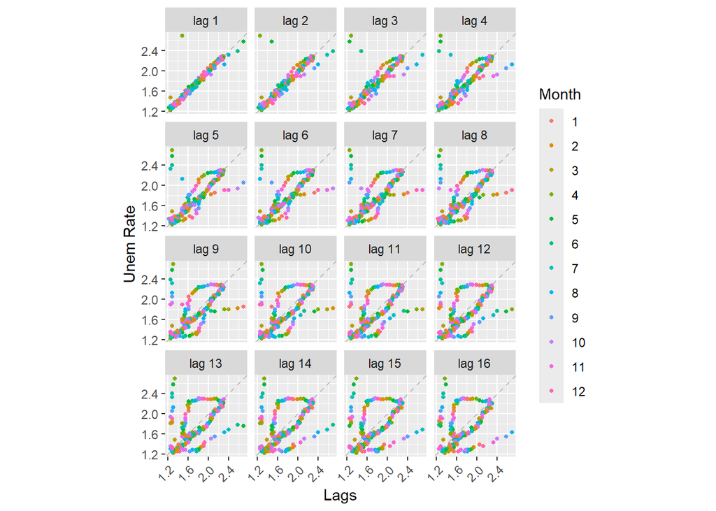

```r
gglagplot(unem_ts, do.lines=FALSE) +
          xlab("Lags")+ylab("Unem Rate") +
          theme(axis.text.x=element_text(angle=45, hjust=1))
```

**CPI**

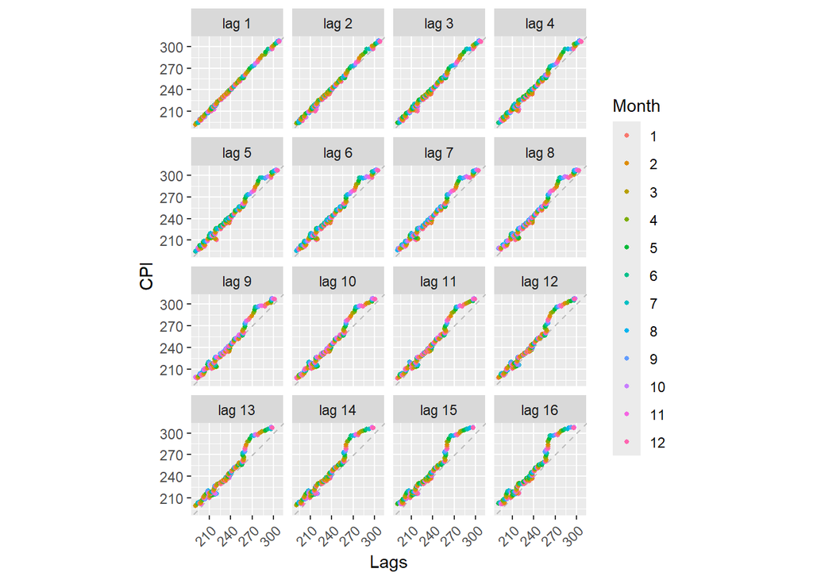

```r
gglagplot(cpi_ts, do.lines=FALSE) +
          xlab("Lags")+ylab("CPI") +
          theme(axis.text.x=element_text(angle=45, hjust=1))
```

**S&P 500**

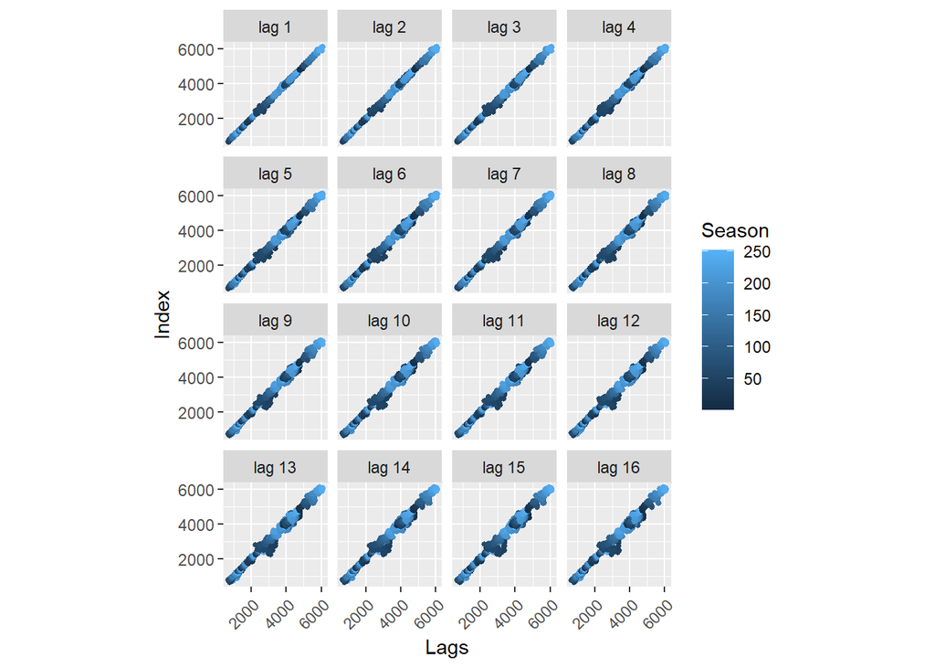

```r
gglagplot(sp5_ts, do.lines=FALSE) +
          xlab("Lags")+ylab("Index") +
          theme(axis.text.x=element_text(angle=45, hjust=1))
```

The lag plot of the S&P 500 index shows perfect positive autocorrelation up to lag 16, indicating that past values are strongly correlated with future values over an extended period. Financial data, like the S&P 500, often exhibit such behavior due to the presence of a unit root, which implies that the time series is non-stationary and tends to follow a random walk. As a result, financial data generally shows long-lasting autocorrelation, where shocks or changes in the data persist over time.

**Gold Price**

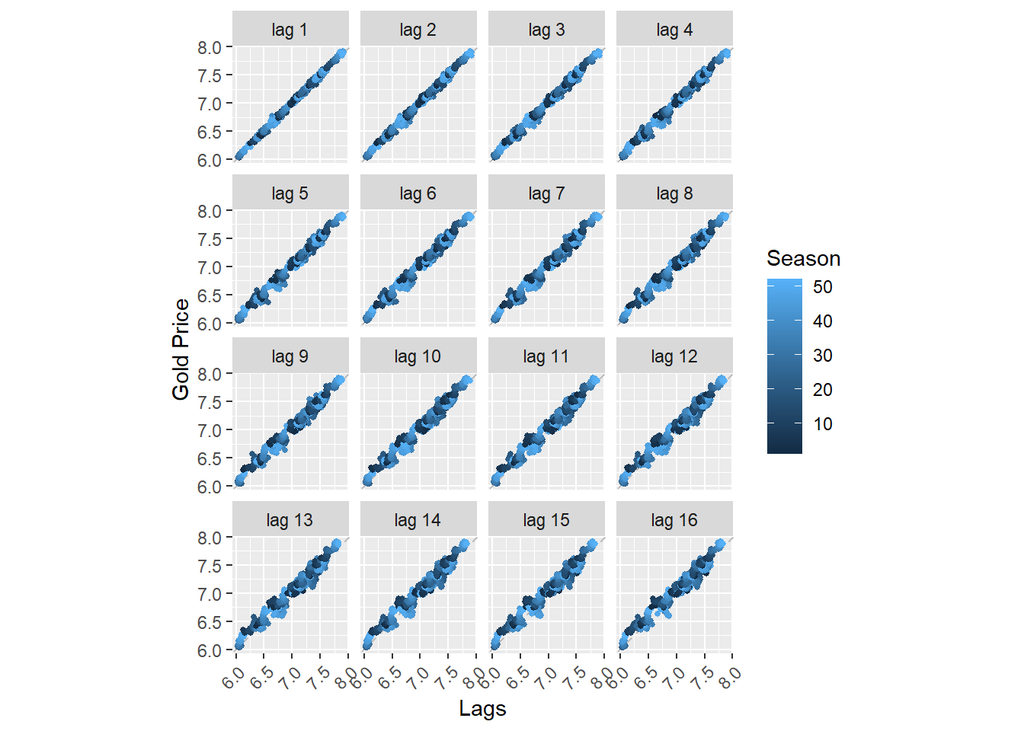

```r
gglagplot(xau_ts, do.lines=FALSE) +
          xlab("Lags")+ylab("Gold Price") +
          theme(axis.text.x=element_text(angle=45, hjust=1))
```

The lag plot of the Spot Gold Price shows perfect positive autocorrelation up to lag 16, indicating that past values are strongly correlated with future values over an extended period. Financial data often exhibit such behavior due to the presence of a unit root, which implies that the time series is non-stationary and tends to follow a random walk. As a result, financial data generally shows long-lasting autocorrelation, where shocks or changes in the data persist over time.

**Global Commodity Price**

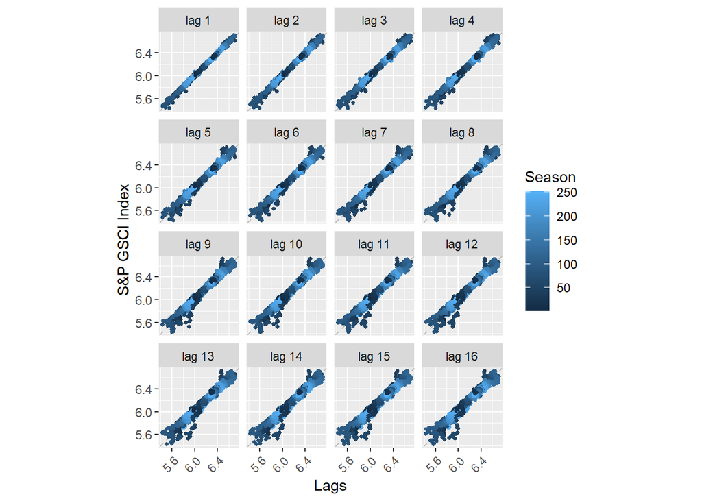

```r
gglagplot(gsci_ts, do.lines=FALSE) +
          xlab("Lags")+ylab("S&P GSCI Index") +
          theme(axis.text.x=element_text(angle=45, hjust=1))
```

The lag plot of the S&P GSCI Index shows perfect positive autocorrelation up to lag 16, indicating that past values are strongly correlated with future values over an extended period. Financial data often exhibit such behavior due to the presence of a unit root, which implies that the time series is non-stationary and tends to follow a random walk. As a result, financial data generally shows long-lasting autocorrelation, where shocks or changes in the data persist over time.

**House Price**

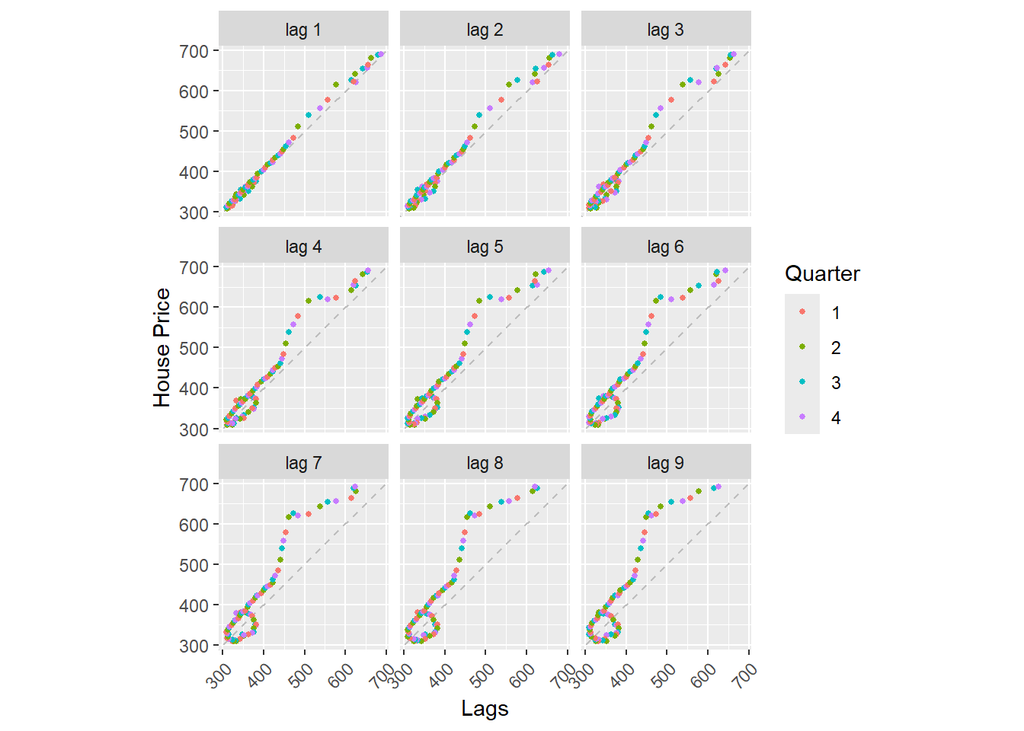

```r
gglagplot(house_ts, do.lines=FALSE) +
          xlab("Lags")+ylab("House Price") +
          theme(axis.text.x=element_text(angle=45, hjust=1))
```

The lag plot of the House Price Index shows perfect positive autocorrelation at lag 1, indicating a strong influence of the previous period on the current value. However, as the lags increase, the autocorrelation gradually weakens, suggesting that the impact of past values diminishes over time. This means that short-term trends in house prices are closely linked to previous values, but the relationship becomes weaker as time moves forward.

**International Visitors**

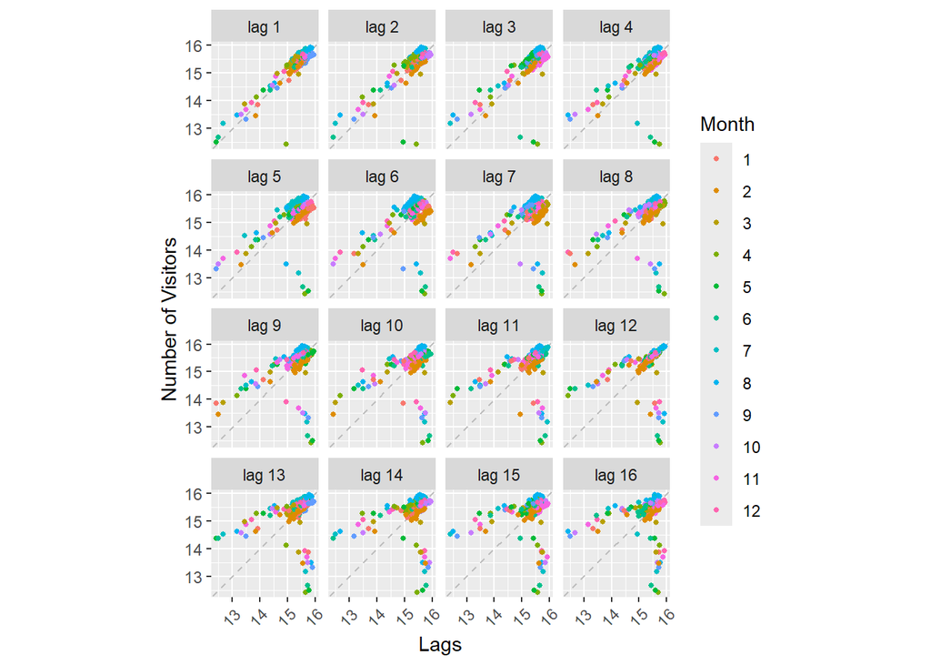

```r
gglagplot(visitors_ts, do.lines=FALSE) +
          xlab("Lags")+ylab("Number of Visitors") +
          theme(axis.text.x=element_text(angle=45, hjust=1))
```

The lag plot of the number of international visitors shows strong autocorrelation in the first four lags, but this correlation gradually weakens as the lags increase. Monthly seasonality is not very noticeable in the plot, possibly because the points are clustered together, making it harder to detect clear seasonal patterns. This suggests that while past values influence the current data for the short term, the effect diminishes over time.

## 3. Decomposition

**U.S. Dollar Index**

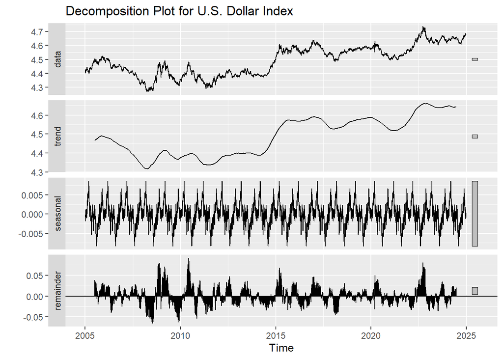

```r
decomposed <- decompose(dxy_ts)
autoplot(decomposed, main = "Decomposition Plot for U.S. Dollar Index")
```

**Trade Balance**

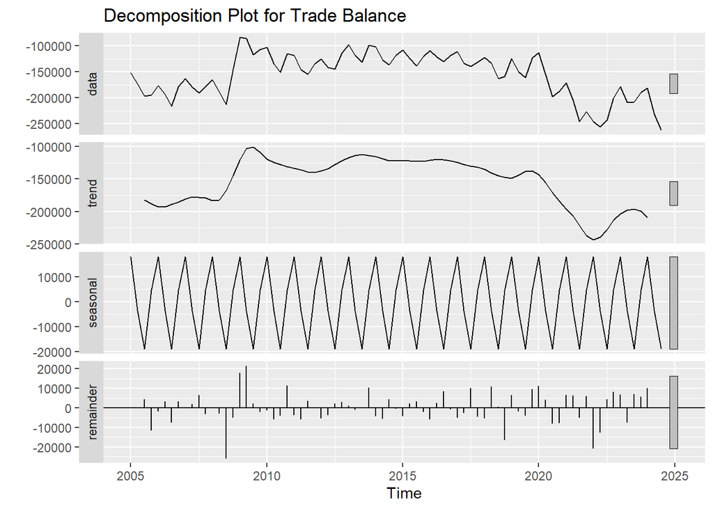

```r
decomposed <- decompose(balance_ts)
autoplot(decomposed, main = "Decomposition Plot for Trade Balance")
```

**GDP**

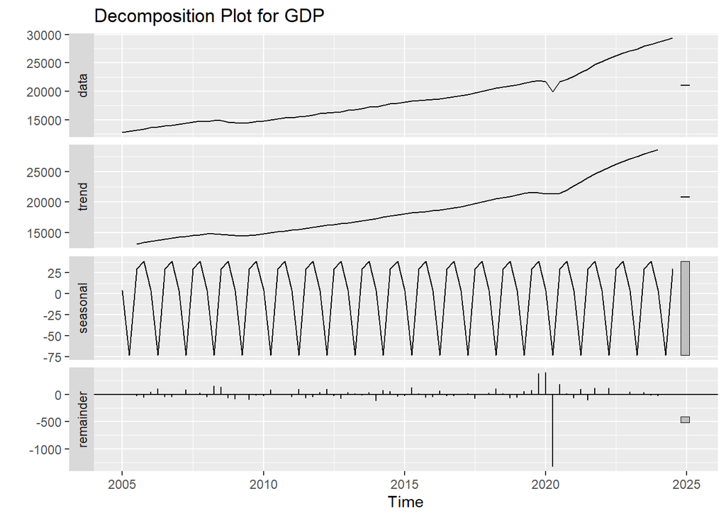

```r
decomposed <- decompose(gdp_ts)
autoplot(decomposed, main = "Decomposition Plot for GDP")
```

**Unemployment Rate**

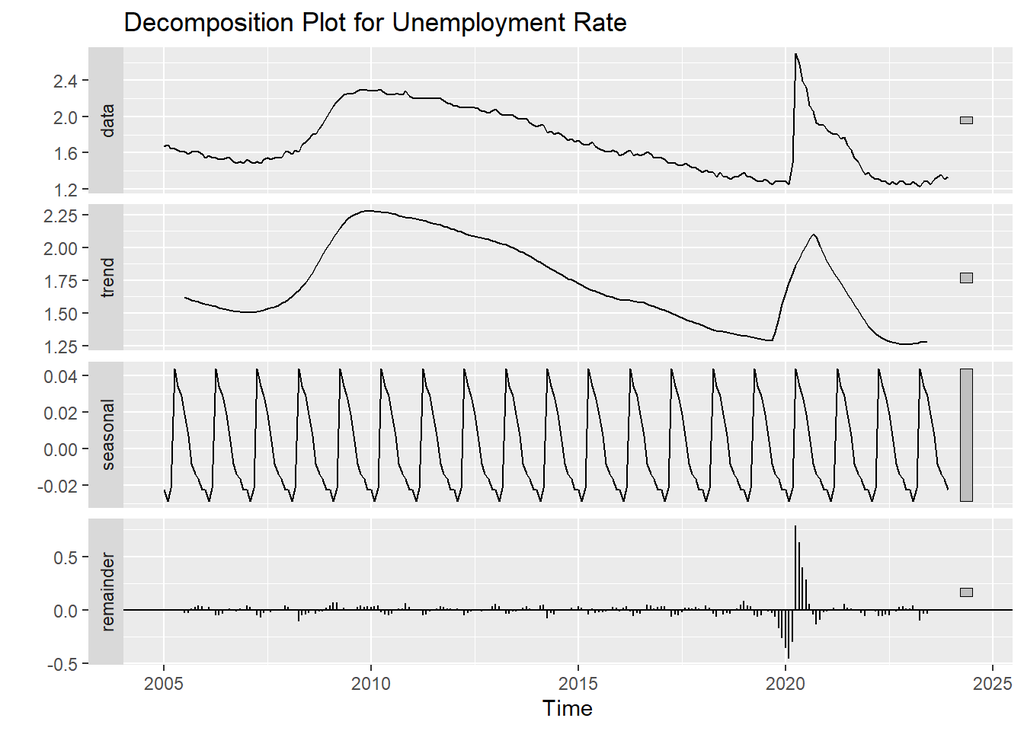

```r
decomposed <- decompose(unem_ts)
autoplot(decomposed, main = "Decomposition Plot for Unemployment Rate")
```

**CPI**

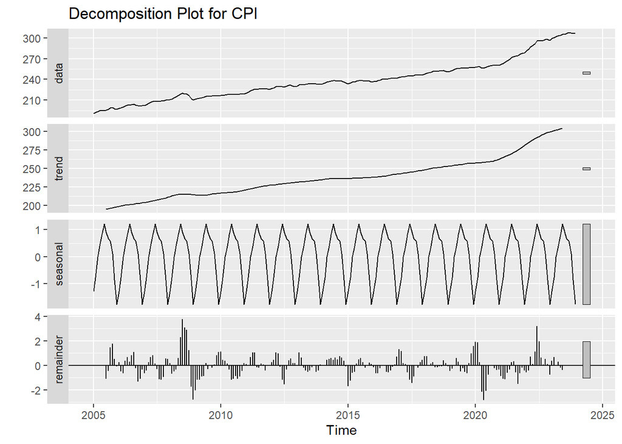

```r
decomposed <- decompose(cpi_ts)
autoplot(decomposed, main = "Decomposition Plot for CPI")
```

**S&P 500**

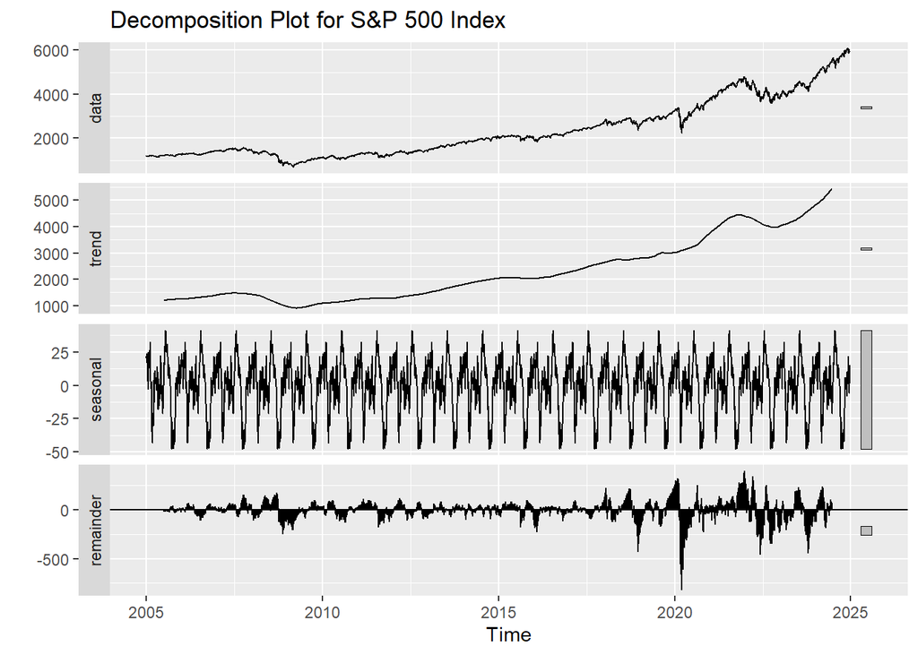

```r
decomposed <- decompose(sp5_ts)
autoplot(decomposed, main = "Decomposition Plot for S&P 500 Index")
```

**Gold Price**

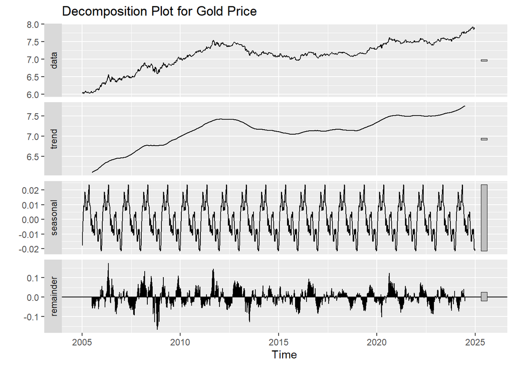

```r
decomposed <- decompose(xau_ts)
autoplot(decomposed, main = "Decomposition Plot for Gold Price")
```

**Global Commodity Price**

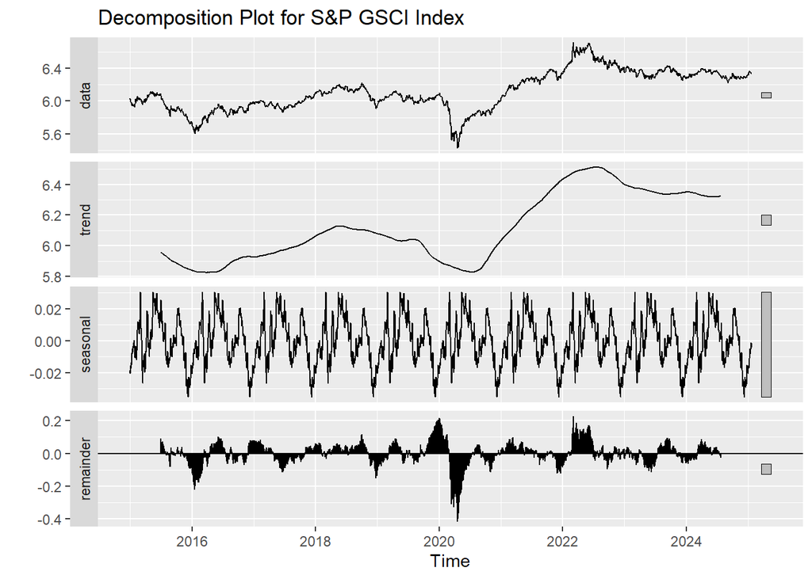

```r
decomposed <- decompose(gsci_ts)
autoplot(decomposed, main = "Decomposition Plot for S&P GSCI Index")
```

**House Price**

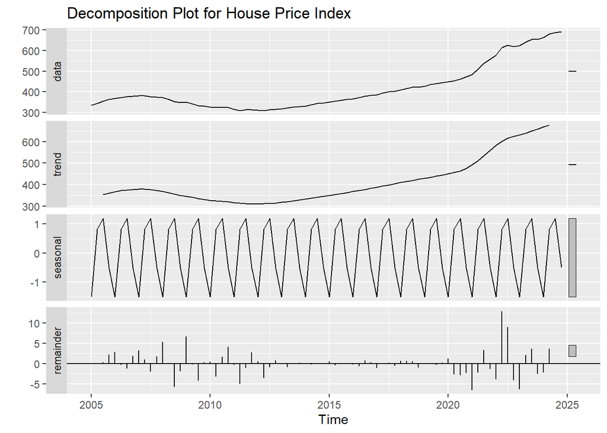

```r
decomposed <- decompose(house_ts)
autoplot(decomposed, main = "Decomposition Plot for House Price Index")
```

**International Visitors**

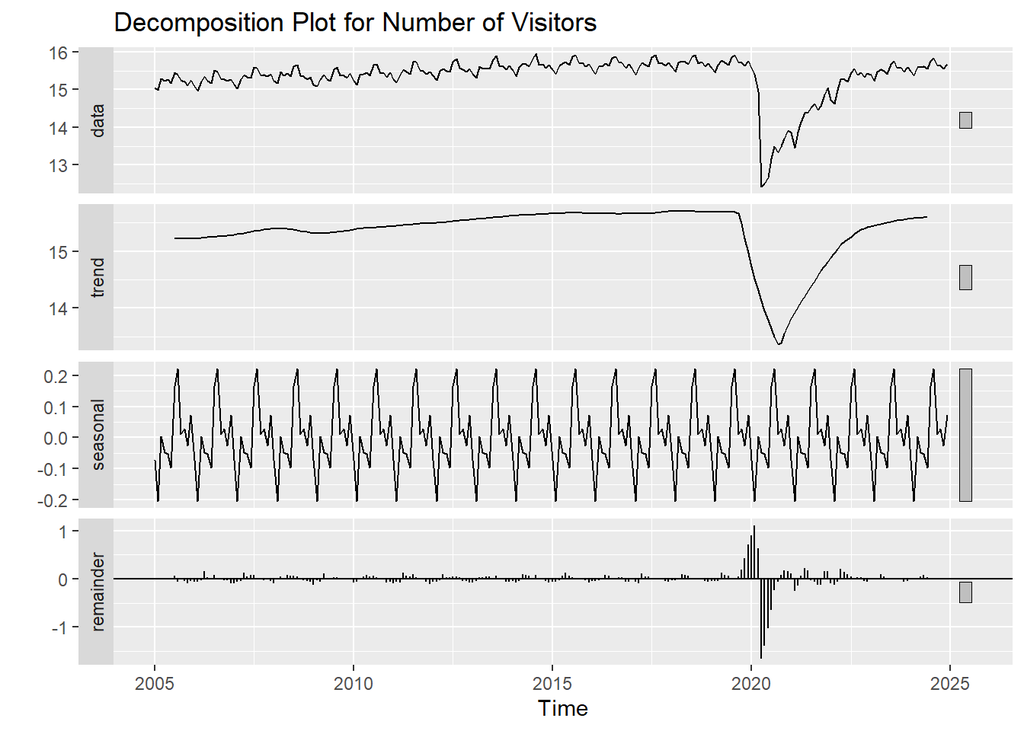

```r
decomposed <- decompose(visitors_ts)
autoplot(decomposed, main = "Decomposition Plot for Number of Visitors")
```

For all of the data series, these decomposition plots generally align with the conclusions we discussed earlier. They confirm the observed trends, seasonality, and the diminishing impact of past values over time. The decompositions help to visualize the underlying components of each series, such as the trend, seasonality, and residuals, further supporting our initial analysis of the data patterns.

## 4. ACF and PACF Plots

**U.S. Dollar Index**

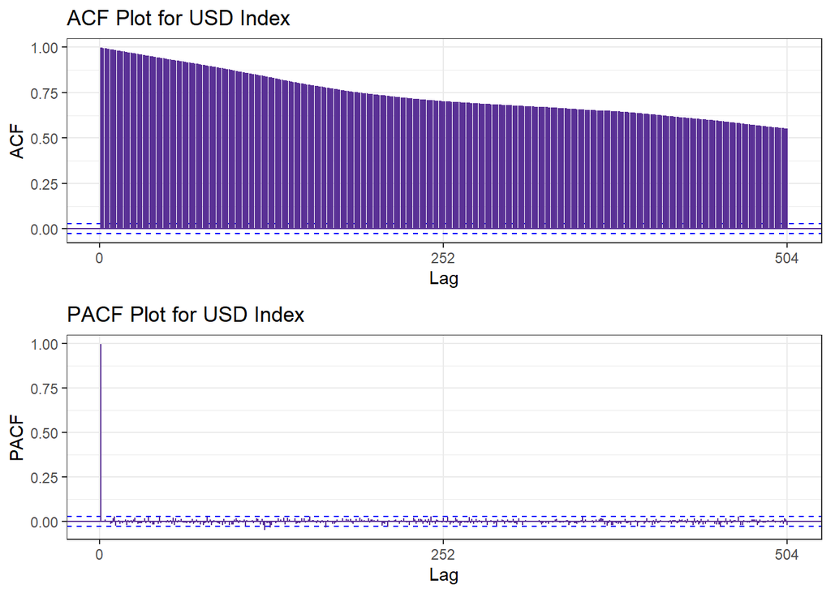

```r
library(gridExtra)

acf <- ggAcf(dxy_ts)+ggtitle("ACF Plot for USD Index") + theme_bw()+
  geom_segment(lineend = "butt", color = "#5a3196") +
    geom_hline(yintercept = 0, color = "#5a3196")
pacf <- ggPacf(dxy_ts)+ggtitle("PACF Plot for USD Index") + theme_bw()+
  geom_segment(lineend = "butt", color = "#5a3196") +
    geom_hline(yintercept = 0, color = "#5a3196")
grid.arrange(acf, pacf, nrow=2)
```

The ACF plot for the USD Index shows a very slow decay over time, indicating that the autocorrelation remains high across many lags. The PACF plot, on the other hand, shows a significant value only at lag 1, with the values rapidly approaching zero after that. This suggests that the U.S. Dollar Index time series is non-stationary, likely exhibiting a unit root. Such behavior is typical for financial data, where past values have a lasting influence on future values, reflecting the persistent nature of trends in these types of series.

**Trade Balance**

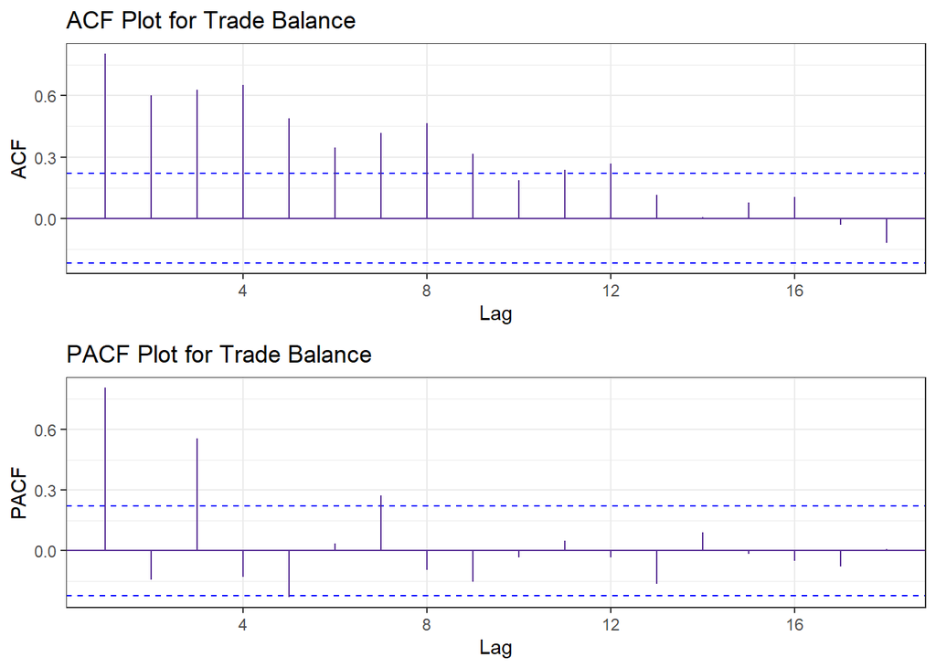

```r
acf <- ggAcf(balance_ts)+ggtitle("ACF Plot for Trade Balance") + theme_bw()+
  geom_segment(lineend = "butt", color = "#5a3196") +
    geom_hline(yintercept = 0, color = "#5a3196")
pacf <- ggPacf(balance_ts)+ggtitle("PACF Plot for Trade Balance") + theme_bw()+
  geom_segment(lineend = "butt", color = "#5a3196") +
    geom_hline(yintercept = 0, color = "#5a3196")
grid.arrange(acf, pacf, nrow=2)
```

The ACF plot for the trade balance shows significant autocorrelation even at lag 12, indicating a long-lasting influence. The PACF plot reveals significant values at lags 1, 3, and 7, suggesting partial relationships at these specific lags.

**GDP**

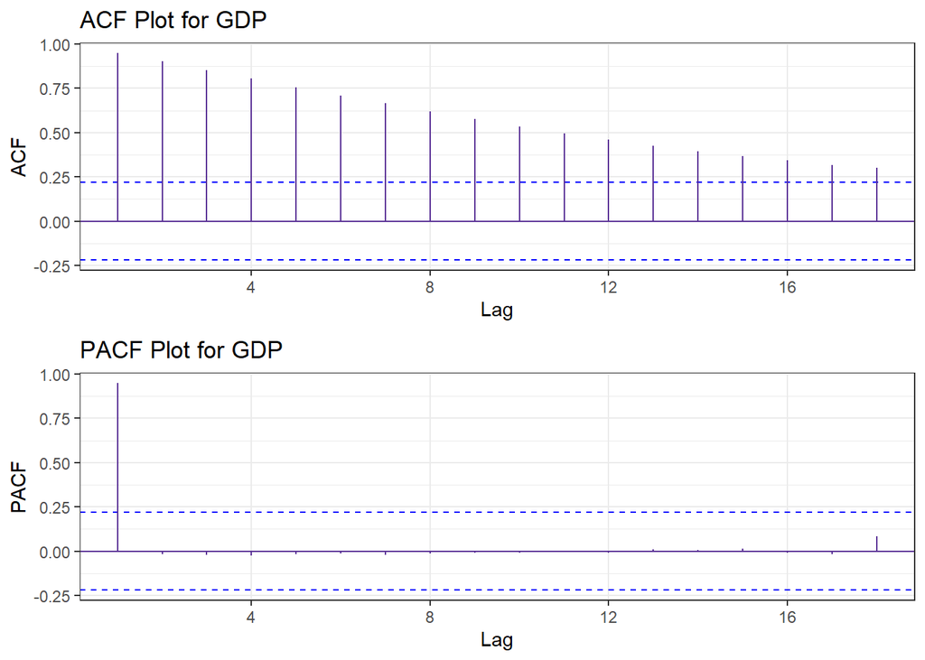

```r
acf <- ggAcf(gdp_ts)+ggtitle("ACF Plot for GDP") + theme_bw()+
  geom_segment(lineend = "butt", color = "#5a3196") +
    geom_hline(yintercept = 0, color = "#5a3196")
pacf <- ggPacf(gdp_ts)+ggtitle("PACF Plot for GDP") + theme_bw()+
  geom_segment(lineend = "butt", color = "#5a3196") +
    geom_hline(yintercept = 0, color = "#5a3196")
grid.arrange(acf, pacf, nrow=2)
```

The ACF plot shows a very slow decay over time, meaning autocorrelation remains high for many lags and decays very slowly towards zero. The PACF plot shows a significant value at lag 1, and then the values will rapidly approach zero. Only the first lag is significant, and the rest are close to zero. This indicates that the GDP time series is non-stationary, and it may be unit root non-stationary.

**Unemployment Rate**

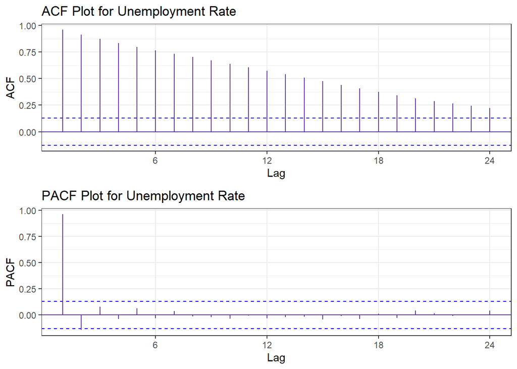

```r
acf <- ggAcf(unem_ts)+ggtitle("ACF Plot for Unemployment Rate") + theme_bw()+
  geom_segment(lineend = "butt", color = "#5a3196") +
    geom_hline(yintercept = 0, color = "#5a3196")
pacf <- ggPacf(unem_ts)+ggtitle("PACF Plot for Unemployment Rate") + theme_bw()+
  geom_segment(lineend = "butt", color = "#5a3196") +
    geom_hline(yintercept = 0, color = "#5a3196")
grid.arrange(acf, pacf, nrow=2)
```

The ACF plot shows a very slow decay over time, meaning autocorrelation remains high for many lags and decays very slowly towards zero. The PACF plot shows a significant value at lag 1, and then the values will rapidly approach zero. Only the first lag is significant, and the rest are close to zero. This indicates that the Unemployment Rate time series is non-stationary, and it may be unit root non-stationary.

**CPI**

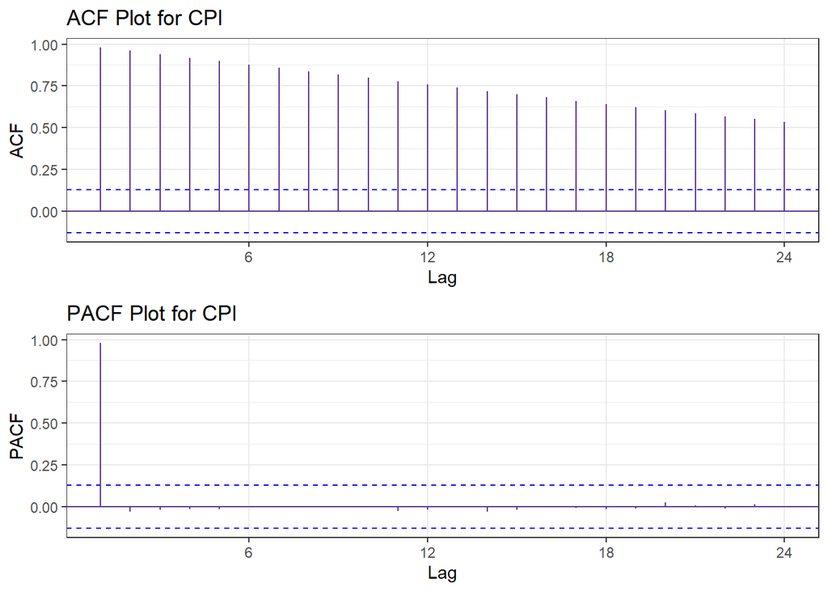

```r
acf <- ggAcf(cpi_ts)+ggtitle("ACF Plot for CPI") + theme_bw()+
  geom_segment(lineend = "butt", color = "#5a3196") +
    geom_hline(yintercept = 0, color = "#5a3196")
pacf <- ggPacf(cpi_ts)+ggtitle("PACF Plot for CPI") + theme_bw()+
  geom_segment(lineend = "butt", color = "#5a3196") +
    geom_hline(yintercept = 0, color = "#5a3196")
grid.arrange(acf, pacf, nrow=2)
```

The ACF plot shows a very slow decay over time, meaning autocorrelation remains high for many lags and decays very slowly towards zero. The PACF plot shows a significant value at lag 1, and then the values will rapidly approach zero. Only the first lag is significant, and the rest are close to zero. This indicates that the CPI time series is non-stationary, and it may be unit root non-stationary.

**S&P 500**

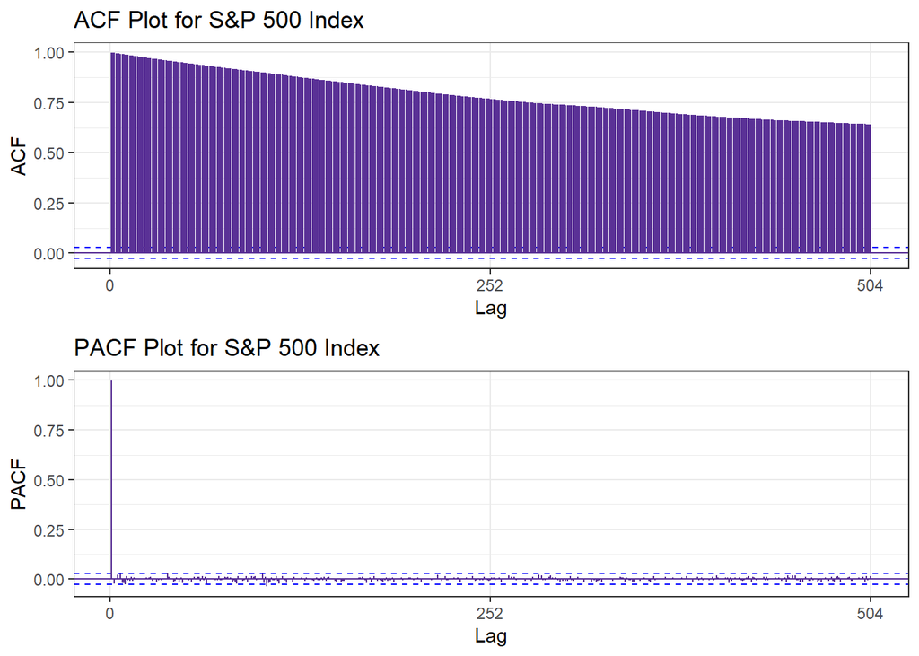

```r
acf <- ggAcf(sp5_ts)+ggtitle("ACF Plot for S&P 500 Index") + theme_bw()+
  geom_segment(lineend = "butt", color = "#5a3196") +
    geom_hline(yintercept = 0, color = "#5a3196")
pacf <- ggPacf(sp5_ts)+ggtitle("PACF Plot for S&P 500 Index") + theme_bw()+
  geom_segment(lineend = "butt", color = "#5a3196") +
    geom_hline(yintercept = 0, color = "#5a3196")
grid.arrange(acf, pacf, nrow=2)
```

The ACF plot shows a very slow decay over time, meaning autocorrelation remains high for many lags and decays very slowly towards zero. The PACF plot shows a significant value at lag 1, and then the values will rapidly approach zero. Only the first lag is significant, and the rest are close to zero. This indicates that the S&P Index is non-stationary, and it may be unit root non-stationary.

**Gold Price**

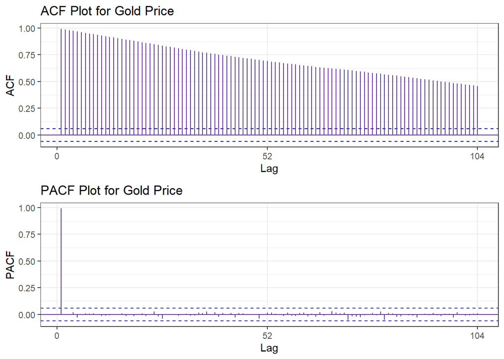

```r
acf <- ggAcf(xau_ts)+ggtitle("ACF Plot for Gold Price") + theme_bw()+
  geom_segment(lineend = "butt", color = "#5a3196") +
    geom_hline(yintercept = 0, color = "#5a3196")
pacf <- ggPacf(xau_ts)+ggtitle("PACF Plot for Gold Price") + theme_bw()+
  geom_segment(lineend = "butt", color = "#5a3196") +
    geom_hline(yintercept = 0, color = "#5a3196")
grid.arrange(acf, pacf, nrow=2)
```

The ACF plot shows a very slow decay over time, meaning autocorrelation remains high for many lags and decays very slowly towards zero. The PACF plot shows a significant value at lag 1, and then the values will rapidly approach zero. Only the first lag is significant, and the rest are close to zero. This indicates that the Gold Price time series is non-stationary, and it may be unit root non-stationary.

**Global Commodity Price**

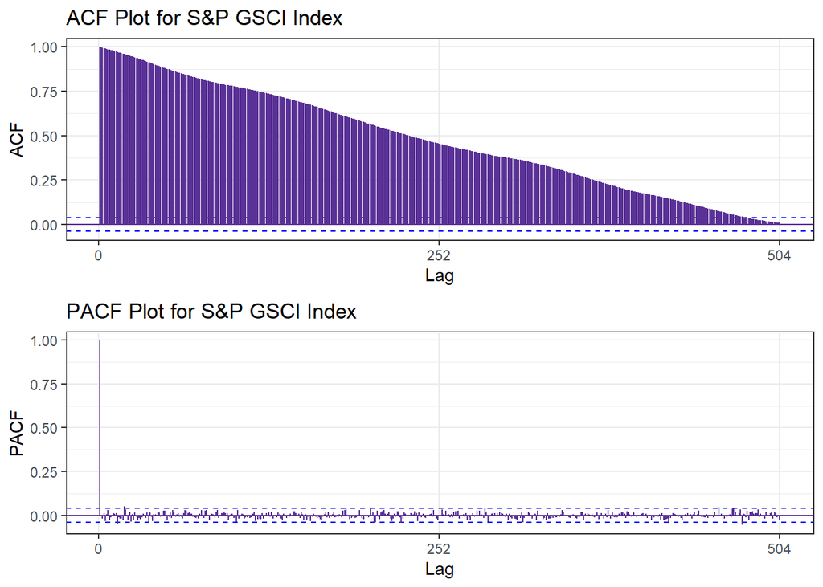

```r
acf <- ggAcf(gsci_ts)+ggtitle("ACF Plot for S&P GSCI Index") + theme_bw()+
  geom_segment(lineend = "butt", color = "#5a3196") +
    geom_hline(yintercept = 0, color = "#5a3196")
pacf <- ggPacf(gsci_ts)+ggtitle("PACF Plot for S&P GSCI Index") + theme_bw()+
  geom_segment(lineend = "butt", color = "#5a3196") +
    geom_hline(yintercept = 0, color = "#5a3196")
grid.arrange(acf, pacf, nrow=2)
```

The ACF plot shows a very slow decay over time, meaning autocorrelation remains high for many lags and decays very slowly towards zero. The PACF plot shows a sharp drop at lag 1, and then the values will rapidly approach zero. Only the first lag is significant, and the rest are close to zero. This indicates that the S&P GSCI Index is non-stationary, and it may be unit root non-stationary.

**House Price**

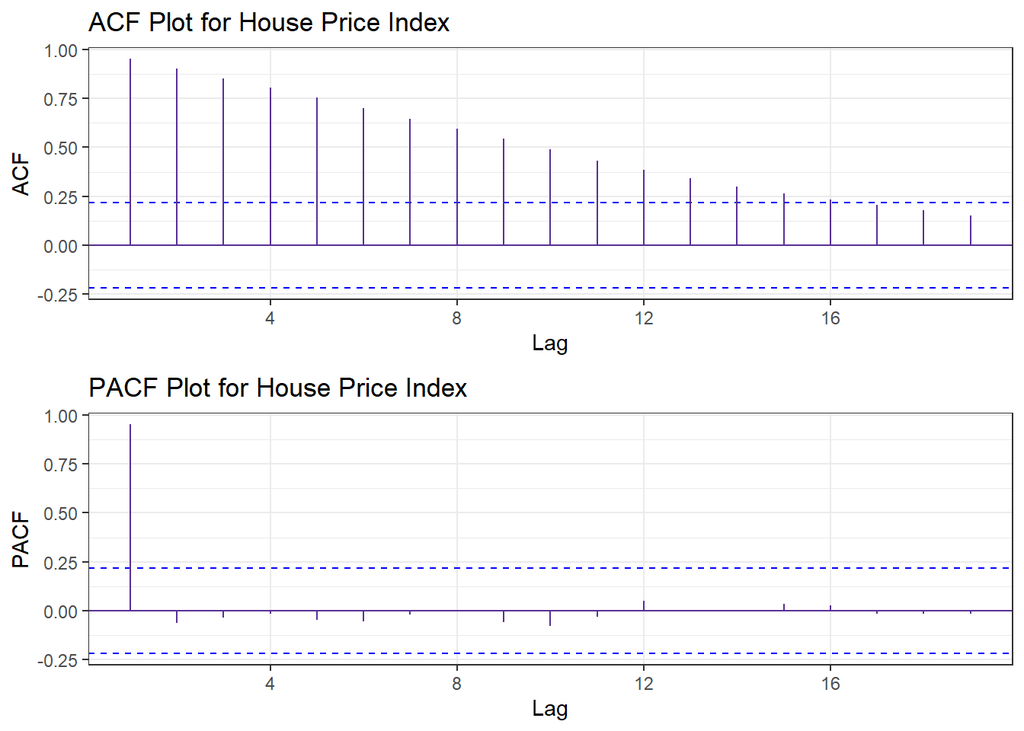

```r
acf <- ggAcf(house_ts)+ggtitle("ACF Plot for House Price Index") + theme_bw()+
  geom_segment(lineend = "butt", color = "#5a3196") +
    geom_hline(yintercept = 0, color = "#5a3196")
pacf <- ggPacf(house_ts)+ggtitle("PACF Plot for House Price Index") + theme_bw()+
  geom_segment(lineend = "butt", color = "#5a3196") +
    geom_hline(yintercept = 0, color = "#5a3196")
grid.arrange(acf, pacf, nrow=2)
```

The ACF plot for the house price remains significant up to lag 16, indicating a long-lasting influence over a considerable number of lags. The PACF plot shows a significant value at lag 1, and then the values will rapidly approach zero. Only the first lag is significant, and the rest are close to zero. This indicates that the house price time series is non-stationary, and it may be unit root non-stationary.

**International Visitors**

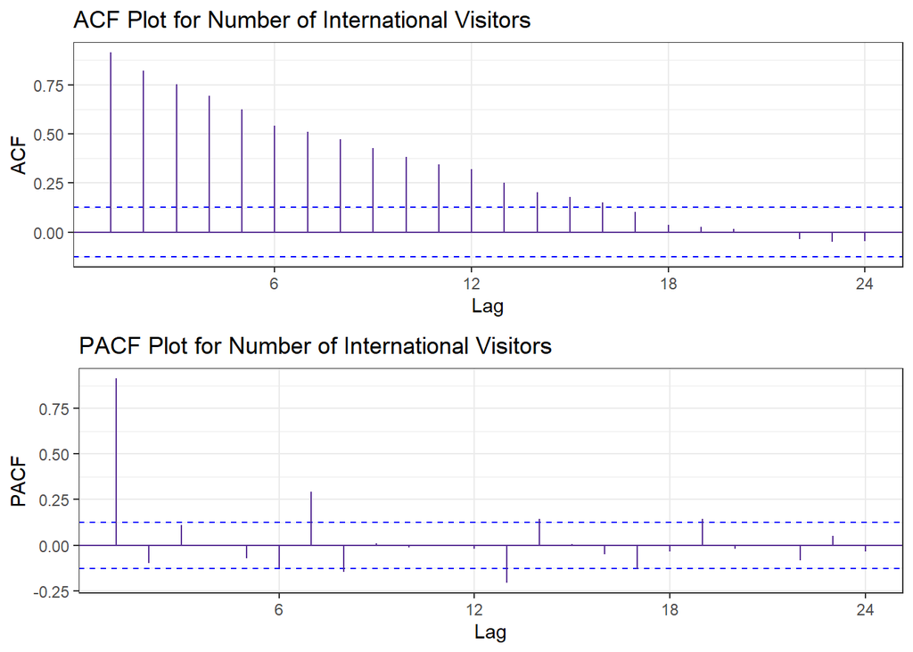

```r
acf <- ggAcf(visitors_ts)+ggtitle("ACF Plot for Number of International Visitors") + theme_bw()+
  geom_segment(lineend = "butt", color = "#5a3196") +
    geom_hline(yintercept = 0, color = "#5a3196")
pacf <- ggPacf(visitors_ts)+ggtitle("PACF Plot for Number of International Visitors") + theme_bw()+
  geom_segment(lineend = "butt", color = "#5a3196") +
    geom_hline(yintercept = 0, color = "#5a3196")
grid.arrange(acf, pacf, nrow=2)
```

Overall, all variables exhibit significant autocorrelation, suggesting that the time series are non-stationary. To make the series stationary, we will need to apply techniques like detrending or differencing. These methods can help remove long-term trends or seasonality, ensuring the data becomes stationary, which is crucial for reliable modeling and forecasting.

## 5. Augmented Dickey-Fuller Test

**U.S. Dollar Index**

```r
library(tseries)
adf.test(dxy_ts)
```

```
    Augmented Dickey-Fuller Test

data:  dxy_ts
Dickey-Fuller = -2.6316, Lag order = 17, p-value = 0.3109
alternative hypothesis: stationary
```

**Trade Balance**

```r
adf.test(balance_ts)
```

```
    Augmented Dickey-Fuller Test

data:  balance_ts
Dickey-Fuller = -2.1307, Lag order = 4, p-value = 0.5222
alternative hypothesis: stationary
```

**GDP**

```r
adf.test(gdp_ts)
```

```
    Augmented Dickey-Fuller Test

data:  gdp_ts
Dickey-Fuller = -0.0084786, Lag order = 4, p-value = 0.99
alternative hypothesis: stationary
```

**Unemployment Rate**

```r
adf.test(unem_ts)
```

```
    Augmented Dickey-Fuller Test

data:  unem_ts
Dickey-Fuller = -2.2088, Lag order = 6, p-value = 0.4882
alternative hypothesis: stationary
```

**CPI**

```r
adf.test(cpi_ts)
```

```
    Augmented Dickey-Fuller Test

data:  cpi_ts
Dickey-Fuller = 0.39171, Lag order = 6, p-value = 0.99
alternative hypothesis: stationary
```

**S&P 500**

```r
adf.test(sp5_ts)
```

```
    Augmented Dickey-Fuller Test

data:  sp5_ts
Dickey-Fuller = -0.67242, Lag order = 17, p-value = 0.973
alternative hypothesis: stationary
```

**Gold Price**

```r
adf.test(xau_ts)
```

```
    Augmented Dickey-Fuller Test

data:  xau_ts
Dickey-Fuller = -2.186, Lag order = 10, p-value = 0.4996
alternative hypothesis: stationary
```

**Global Commodity Price**

```r
adf.test(gsci_ts)
```

```
    Augmented Dickey-Fuller Test

data:  gsci_ts
Dickey-Fuller = -2.362, Lag order = 13, p-value = 0.4251
alternative hypothesis: stationary
```

**House Price**

```r
adf.test(house_ts)
```

```
    Augmented Dickey-Fuller Test

data:  house_ts
Dickey-Fuller = -1.3735, Lag order = 4, p-value = 0.832
alternative hypothesis: stationary
```

**International Visitors**

```r
adf.test(visitors_ts)
```

```
    Augmented Dickey-Fuller Test

data:  visitors_ts
Dickey-Fuller = -2.4163, Lag order = 6, p-value = 0.4008
alternative hypothesis: stationary
```

The p-values in the ADF (Augmented Dickey-Fuller) tests for all variables are above 0.05, which means we fail to reject the null hypothesis of the test. This indicates that the time series for all variables are non-stationary, which is consistent with our previous observations. To make the time series stationary, we need to apply differencing, which helps remove trends and make the data more stable over time. Therefore, differencing is necessary to achieve stationarity before proceeding with further time series analysis.

## 6. Differencing

**U.S. Dollar Index**

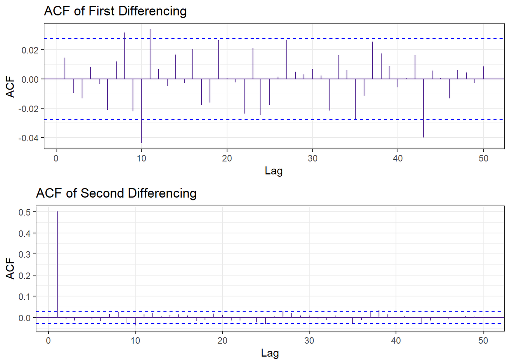

```r
diff1 <- ggAcf(diff(dxy_ts), 50, main="ACF of First Differencing")+ theme_bw()+
  geom_segment(lineend = "butt", color = "#5a3196") +
    geom_hline(yintercept = 0, color = "#5a3196")
diff2 <- ggAcf(diff(dxy_ts, 2), 50, main="ACF of Second Differencing")+ theme_bw()+
  geom_segment(lineend = "butt", color = "#5a3196") +
    geom_hline(yintercept = 0, color = "#5a3196")
grid.arrange(diff1, diff2, nrow=2)
```

**Trade Balance**

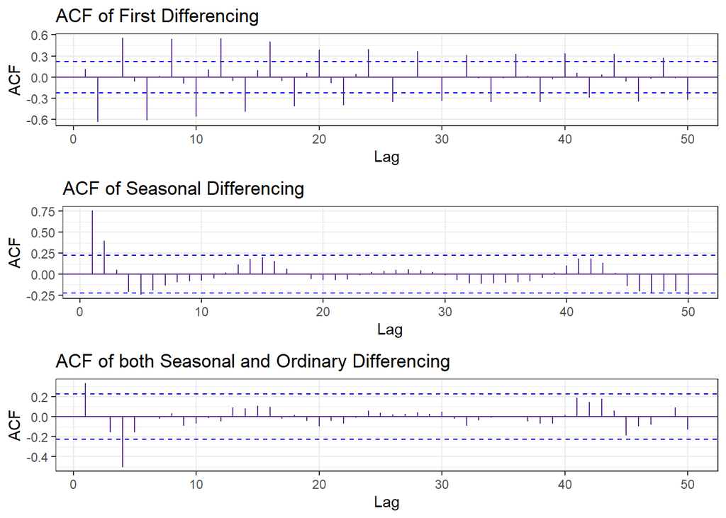

```r
diff1 <- ggAcf(diff(balance_ts), 50, main="ACF of First Differencing")+ theme_bw()+
  geom_segment(lineend = "butt", color = "#5a3196") +
    geom_hline(yintercept = 0, color = "#5a3196")
diff2 <- ggAcf(diff(balance_ts, lag=4), 50, main="ACF of Seasonal Differencing")+ theme_bw()+
  geom_segment(lineend = "butt", color = "#5a3196") +
    geom_hline(yintercept = 0, color = "#5a3196")
diff3 <- ggAcf(diff(diff(balance_ts, lag=4)), 50, main="ACF of both Seasonal and Ordinary Differencing")+ theme_bw()+
  geom_segment(lineend = "butt", color = "#5a3196") +
    geom_hline(yintercept = 0, color = "#5a3196")
grid.arrange(diff1, diff2, diff3, nrow=3)
```

For the trade balance, the ACF plot after first differencing still exhibits significant seasonality, suggesting that seasonal differencing is required. Applying both seasonal differencing and first-order differencing together proves effective, as most of the ACF values become insignificant. Only two lags remain significant, indicating that the series is now much closer to being stationary.

**GDP**